# Homework 5

DACSS-601

Katie Popiela  
4/27/2022

```r
library(tidyverse)
library(dplyr)
library(poliscidata)
gss %>%
  select(sex,polviews,degree) %>%
  head(25) %>%
  tibble()
```

```
# A tibble: 25 x 3
   sex    polviews  degree
   <fct>  <fct>     <fct>
 1 Male   Moderate  Bachelor deg
 2 Male   SlghtCons HS
 3 Male   SlghtCons HS
 4 Female SlghtCons HS
 5 Female Liberal   Bachelor deg
 6 Female Moderate  Bachelor deg
 7 Female Moderate  Junior Coll
 8 Female Moderate  <HS
 9 Female Conserv   <HS
10 Female Liberal   Bachelor deg
# ... with 15 more rows
```

```r
library(poliscidata)
data(gss)
gss_refined<-gss %>%
  select(polviews,sex,degree)
summary(gss_refined)
```

```
      polviews       sex                degree
 Moderate :713   Male  : 886   <HS         :288
 Conserv  :292   Female:1088   HS          :976
 SlghtCons:268                 Junior Coll :151
 Liberal  :244                 Bachelor deg:354
 SlghtLib :208                 Graduate deg:205
 (Other)  :149
 NA's     :100
```

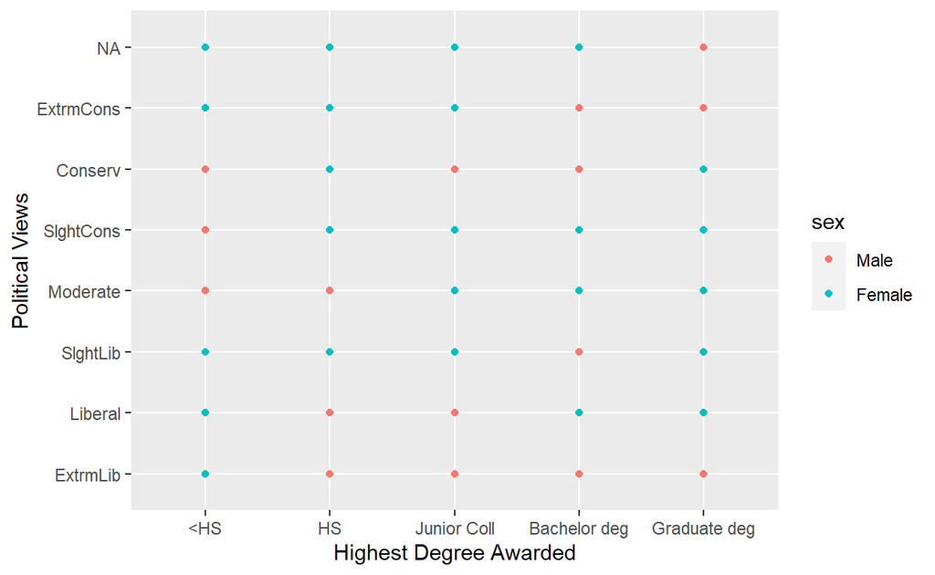

```r
library(poliscidata)
ggplot(gss_refined) + geom_point(aes(x=degree, y=polviews,color=sex)) +
  labs(x="Highest Degree Awarded",y="Political Views") +
  facet_grid()
```

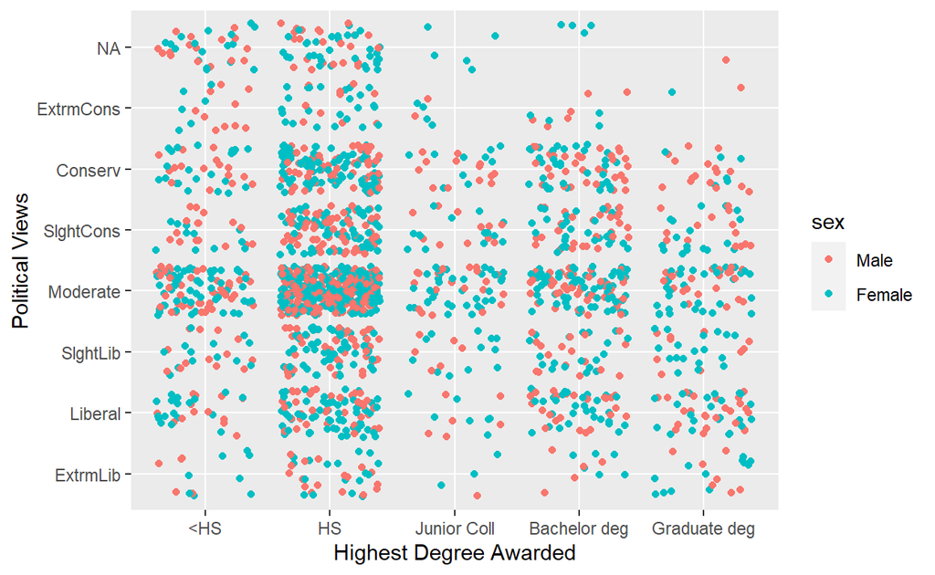

```r
data(gss)
ggplot(gss_refined) + geom_jitter(aes(x=degree, y=polviews,color=sex)) +
  labs(x="Highest Degree Awarded",y="Political Views") +
  facet_grid()
```

*Note: I think the above graph is the best one this far, but I’m going to try to tweak it to make it a little more precise*

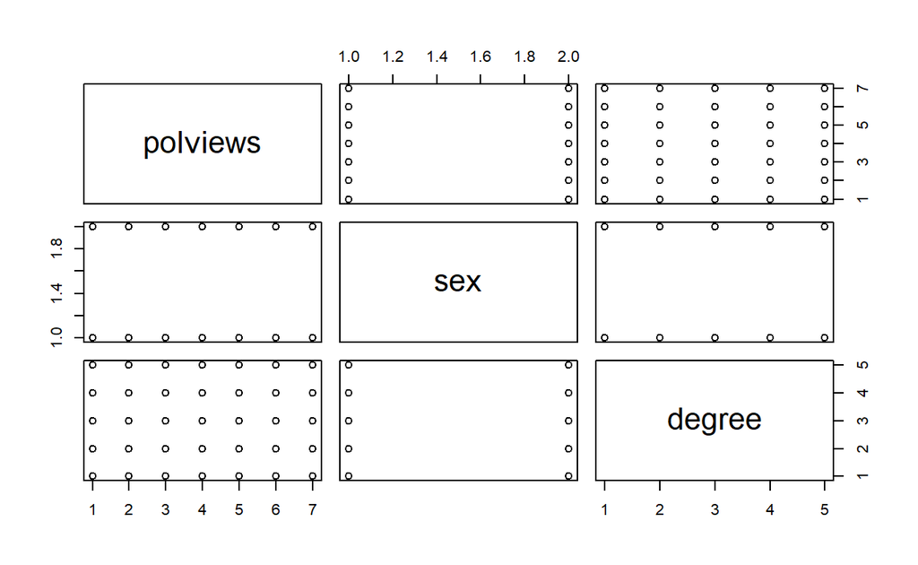

```r
gss_refined%>%
  pairs()
```

**1.** I don’t think anything is missing from my analysis, I’m just trying to see if there’s a better way to visualize everything. There may not be a better way, but I’m going to use these homeworks to keep trying!

**3.** A reader without any context would at the very least need some understanding of the current political trends in the US (e.g. the rise of conservatism and the rise of far-left socialism among Gen Z/younger generations).

**4.** I’d like to incorporate how age plays a part in all this but I couldn’t figure out how to graph 4 different variables.